# Differential methylation and Horvath’s Clock

Carlos Neves

# Introduction

DNA methylation is a chemical modification of DNA which in humans is known to occurs at CpG dinucleotides where the cytosine can be methylated to 5-methylcytosine. The [Illumina 450k DNA methylation microarray](https://www.illumina.com/documents/products/datasheets/datasheet_humanmethylation450.pdf) is a cheap and relatively comprehensive array for assaying DNA methylation. It is the platform of choice for large sample profiling of DNA methylation, especially for epigenome-wide association studies (EWAS) which look for associations between phenotype with epigenotype. This report is a simple analysis focusing on data from Illumina 450K methylation arrays using blood samples from GSE68777 to analyse the methylation profiles, age and cell composition of patient samples. These data include serum samples obtained from individuals hospitalized with acute mania as well as unaffected controls.

### Load Dependencies

```r
library(minfi)
library(tidyverse)
library(GEOquery)
library(ComplexHeatmap)
library(circlize)
library(sva)
library(WGCNA)
library(sqldf)
library(impute)
library(FlowSorted.Blood.450k)
library(limma)
library(doParallel)
library(reshape)
registerDoParallel(cores = detectCores())
set.seed(1)
```

### Helper functions

A wrapper function to estimate the DNA methylation *(DNAm)* age needs to be defined based on the method provided in [Horvath 2013](https://www.ncbi.nlm.nih.gov/pmc/articles/PMC4015143/) as a R package is not available for use. All files required can be downloaded from the [report on the github repository](https://github.com/CN3ves/DataProjects/tree/master/reports) or adapted from the supplementary information provided on the original publication.

```r
source("DNAage.R")
```

In addition, there seems to be a small bug on the plotSex function from *minfi* R package so it needs to be re-defined to check the colnames of the object passed to the function correctly Finally, I have adapted the volcanoplot function `splot` from the rafalib package.

```r
# Function to  plot predicted sex from methylation data
plotSex <- function (object, id = NULL)
{
    stopifnot(all(c("predictedSex", "xMed", "yMed") %in% colnames(object)))
    # stopifnot(all(c("predictedSex", "xMed", "yMed") %in% colnames(colData(object))))
    if (is.null(id))
        id <- seq_along(object$predictedSex)
    if (length(id) != length(object$predictedSex)) {
        stop("id length must match number of samples.")
    }
    plot(x = object$xMed, y = object$yMed, type = "n", xlab = "X chr, median total intensity (log2)",
        ylab = "Y chr, median total intensity (log2)")
    text(x = object$xMed, y = object$yMed, labels = id, col = ifelse(object$predictedSex ==
        "M", "deepskyblue", "deeppink3"))
    legend("bottomleft", c("M", "F"), col = c("deepskyblue",
        "deeppink3"), pch = 16)
}

# Function to make a volcano plot
volcano_plot <- function (coeffs, pval, n = 500000, subset = NULL, threshold = 0,
                          xlab = "Effect size", ylab = "-log10(p-value)",  ...) {
  sig <- pval < 0.05
  up <- coeffs > threshold
  down <- coeffs < -threshold
  cols <- ifelse(sig & up, "blue", ifelse(sig & down, "red", "grey"))

  x <- coeffs
  y <- -log10(pval)

  if (!is.null(subset)) {
    x = x[subset]
    y = y[subset]
    cols = cols[subset]
  }
  if (length(x) > n) {
    sigs <- sig & (up | down)
    ind = which(sigs)
    ind = c(ind, sample(which(!sigs), 10000))

    x = x[ind]
    y = y[ind]
    cols = cols[ind]
  }
  plot(x, y, xlab = xlab, ylab = ylab, col = cols, ...)
  abline(h = -log10(0.05))
}
```

## Download Data

[GEO](https://www.ncbi.nlm.nih.gov/geo/) is a public functional genomics data repository containing both array- and sequence-based curated data are accepted. This report will use the data from the study [*“Association of DNA Methylation with Acute Mania and Inflammatory Markers”*](https://journals.plos.org/plosone/article?id=10.1371/journal.pone.0132001), which is available from GEO. The Illumina 450k raw data is stored in .IDAT format files. Because the array is measured in two different colors, there are two files for each sample, typically with the extention _Grn.idat and _Red.idat. Currently the *minfi* R package does not support reading compressed .IDAT raw files so first, these files need to be decompressed.

```r
getGEOSuppFiles("GSE68777")
untar("GSE68777/GSE68777_RAW.tar", exdir = "GSE68777/idat")
idatFiles <- list.files("GSE68777/idat", pattern = "idat.gz$", full = TRUE)
idatFiles <- sapply(idatFiles, gunzip, overwrite = TRUE)
```

```r
head(list.files("GSE68777/idat", pattern = "idat"))
```

```
## [1] "GSM1681154_5958091019_R03C02_Grn.idat"
## [2] "GSM1681154_5958091019_R03C02_Red.idat"
## [3] "GSM1681155_5935446005_R05C01_Grn.idat"
## [4] "GSM1681155_5935446005_R05C01_Red.idat"
## [5] "GSM1681156_5958091020_R01C01_Grn.idat"
## [6] "GSM1681156_5958091020_R01C01_Red.idat"
```

It can be noticed that the filenames consists of a GEO identifier (the GSM part) followed by a standard .IDAT naming convention with a 10 digit number which is the array identifier followed by an the spacial identifier of the form R0XC0Y (each array allows for the hybridization of 12 samples in a 6x2 arrangement). For example the sample 5958091019_R03C02 matches the row 3 and column 2 on chip 5958091019. However, this does not identify the samples. So, in addition to the raw .IDAT files, the patient (phenotype) needs to be taken from the standard GEO representation.

```r
geoMat <- getGEO("GSE68777")
pD <- pData(geoMat[[1]])
# Remove non-informative variables
idx <- sapply(pD, unique)
idx <- sapply(idx, length) == 1
pD <- pD[!idx]

names(pD)
```

```
## [1] "title"                 "geo_accession"         "characteristics_ch1.1"
## [4] "characteristics_ch1.2" "supplementary_file"    "supplementary_file.1"
## [7] "diagnosis:ch1"         "Sex:ch1"
```

Most of the columns in this phenotype data are irrelevant to this report. As such, only *title, sex and diagnosis information* will be kept.

```r
# Keep and rename relevant variables
pD <- pD[, c("title", "diagnosis:ch1","Sex:ch1")]
names(pD)[2:3] <- c("group", "sex")
```

# Reading Data

The starting point of the methylation array analysis is reading the .IDAT files.

```r
rgSet <- read.metharray.exp("GSE68777/idat")
```

After reading the methylation raw data, the phenotypic information is added to the [RGChannelSet](https://www.rdocumentation.org/packages/minfi/versions/1.18.4/topics/RGChannelSet-class) object. This object contains the raw intensities in the green and red channels, the intensities of the internal control probes, experimental and probe information.

```r
# Remove GSM idenfier to simplify sample names
sampleNames(rgSet) <- sub(".*_5", "5", sampleNames(rgSet))
rownames(pD) <- pD$title
# Sort to match RGChannelSet object
pD <- pD[sampleNames(rgSet),]
# Add phenotypic data
pData(rgSet) <- DataFrame(pD)

rgSet
## class: RGChannelSet
## dim: 622399 40
## metadata(0):
## assays(2): Green Red
## rownames(622399): 10600313 10600322 ... 74810490 74810492
## rowData names(0):
## colnames(40): 5958091019_R03C02 5935446005_R05C01 ... 5958091020_R02C02
##   5935403032_R04C01
## colData names(3): title group sex
## Annotation
##   array: IlluminaHumanMethylation450k
##   annotation: ilmn12.hg19
```

# Quality control

The 450k array contains several internal control probes that can be used to assess the quality control of different sample preparation steps (bisulfite conversion, hybridization, etc.) We can see that the distribution of the intensities is consistent among the control probes.

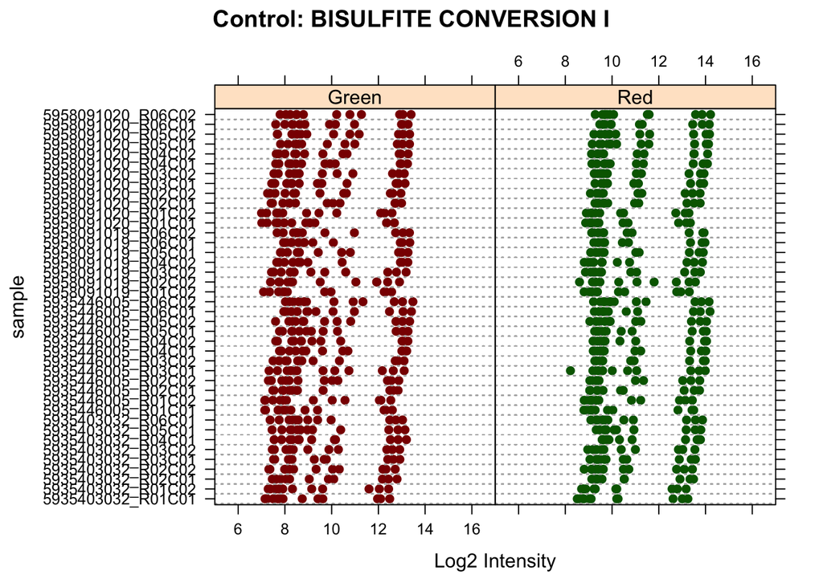

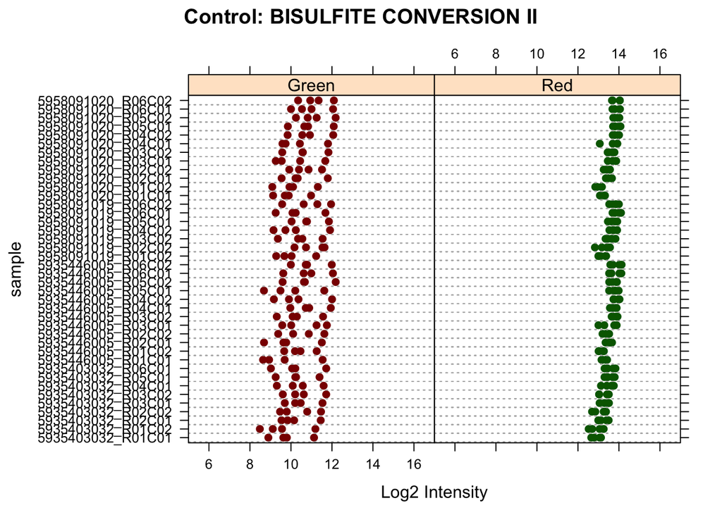

```r
controlStripPlot(rgSet)
```

Another simple quality control uses the log median intensity in both the methylated (M) and unmethylated (U) channels. When plotting these two medians against each other, it has been observed that good samples cluster together, while failed samples tend to separate and have lower median intensities. To do this, the raw signal need to be converted to methylated and unmethylated signals according to the 450K probe design.

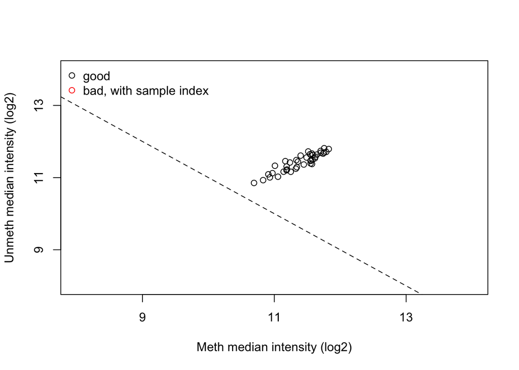

```r
MSet <- preprocessRaw(rgSet)
qc <- getQC(MSet)
plotQC(qc)
```

To further explore the quality of the samples, it is useful to compare the densities of the methylation proportion (beta value) for all sample. Though the methylation state of a given locus in a single cell is binary *(technically tertiary since we have two copies of most chromosomes)*, due to the nature of the experimental methodology, methylation is measured across a heterogeneous population of cells, resulting in an expected distribution of methylation proportions that follows a bimodal distribution with most results either being closer to 0 or to 1.

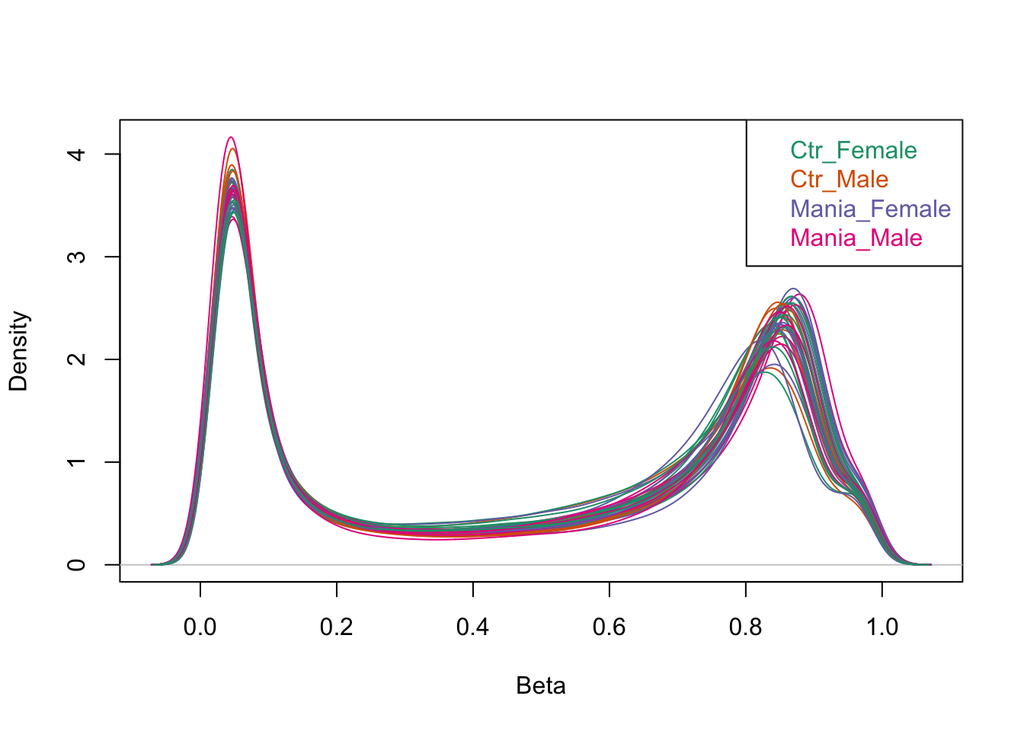

```r
strata <- as.factor(paste(pData(rgSet) $group, pData(rgSet) $sex, sep ="_"))
densityPlot(MSet, sampGroups = strata)
```

The 450k array contains by design 65 probes that are not meant to interrogate methylation status, but instead are designed to interrogate SNPs. These SNP probes are intended to be used for sample tracking and sample mixups. As each SNP probe ought to have values clustered around 3 distinct values corresponding to homo- and hetero-zygotes.

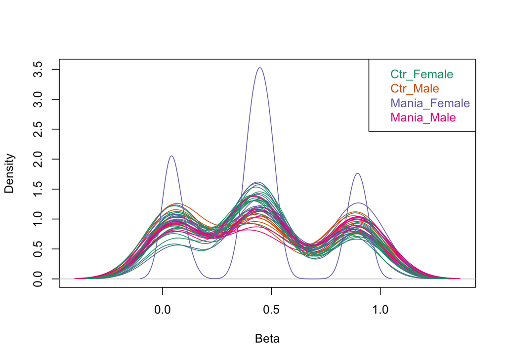

```r
snps <- getSnpBeta(rgSet)
densityPlot(snps, sampGroups = strata)
```

# Preprocessing and normalization

There are a number of different normalisation methods that can be applied to methylation data. If no global differences between samples is expected (for instance a blood dataset or one-tissue dataset) the assumptions for quantile normalization are generally true, so `preprocessQuantile` a suitable normalisation method. It implements stratified quantile normalization preprocessing, where the normalization procedure is applied to the Meth and Unmeth intensities separately and the distribution of type I and type II signals is forced to be the same by stratified quantile normalizing.

```r
GRset <- preprocessQuantile(rgSet, fixOutliers = TRUE,
  removeBadSamples = TRUE, badSampleCutoff = 10.5,
  quantileNormalize = TRUE, stratified = TRUE,
  mergeManifest = FALSE, sex = NULL)
```

The resulting [GenomicRatioSet](https://www.rdocumentation.org/packages/minfi/versions/1.18.4/topics/GenomicRatioSet-class) object is designed to store Beta values and/or M values instead of the methylated and unmethylated signals, where **Beta value**
$$\frac{M}{M + U + 100}$$
and **M value**
$$Mval = \log{\biggl(\frac{M}{U}\biggr)}$$
with $M$ and $U$ denote the methylated and unmethylated signals respectively.

```r
# Methylation values
beta <- getBeta(GRset)
M <- getM(GRset)

# Sample information
sampleNames <- sampleNames(GRset)
pheno <- pData(GRset)
pheno$group <- as.factor(pheno$group)
```

To return the probe locations as a `GenomicRanges` objects, one can use the accessor `granges`:

```r
# Probe information
probeNames <- featureNames(GRset)
gr <- granges(GRset)
head(gr, n= 3)
## GRanges object with 3 ranges and 0 metadata columns:
##              seqnames    ranges strand
##                 <Rle> <IRanges>  <Rle>
##   cg13869341     chr1     15865      *
##   cg14008030     chr1     18827      *
##   cg12045430     chr1     29407      *
##   -------
##   seqinfo: 24 sequences from hg19 genome; no seqlengths
```

## Sex prediction

By looking at the median total intensity of the X chromosome-mapped probes ($med(X)$), and the median total intensity of the Y-chromosome-mapped probes ($med(Y)$), one can observe two different clusters of points corresponding to which gender the samples belong to. A cutoff on $\log_2{med(Y)}-\log_2{med(Y)}$ can be used to predict the gender based on these values.

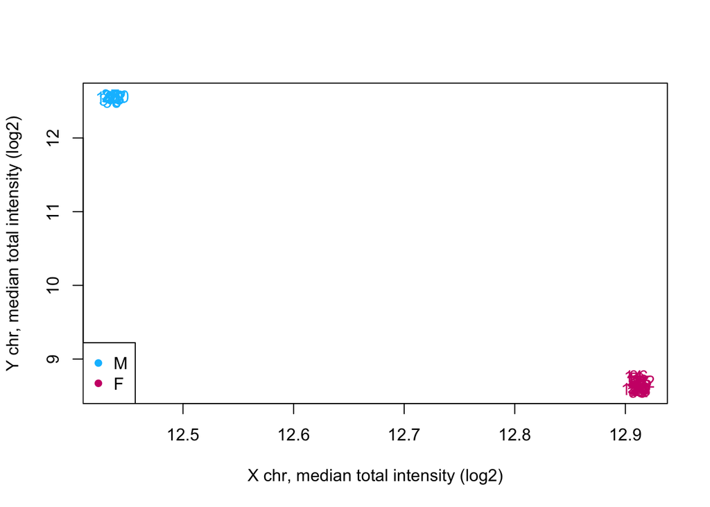

```r
gender <- getSex(GRset, cutoff = -2)
plotSex(gender)
```

As a sanity check, we can compare the estimated sex with the sex recorded in the phenotypic data, which to match perfectly.

```r
table(gender$predictedSex, pheno$sex)
```

```
##
##     Female Male
##   F     26    0
##   M      0   14
```

## Multidimensional Scaling

The methylation beta values can be represented at lower dimentions for exploratory analysis and visualisation. A principal coordinates analysis, which projects the distances between samples into a two-dimentional space, can be performed to better understand the relationship between the all patient samples.

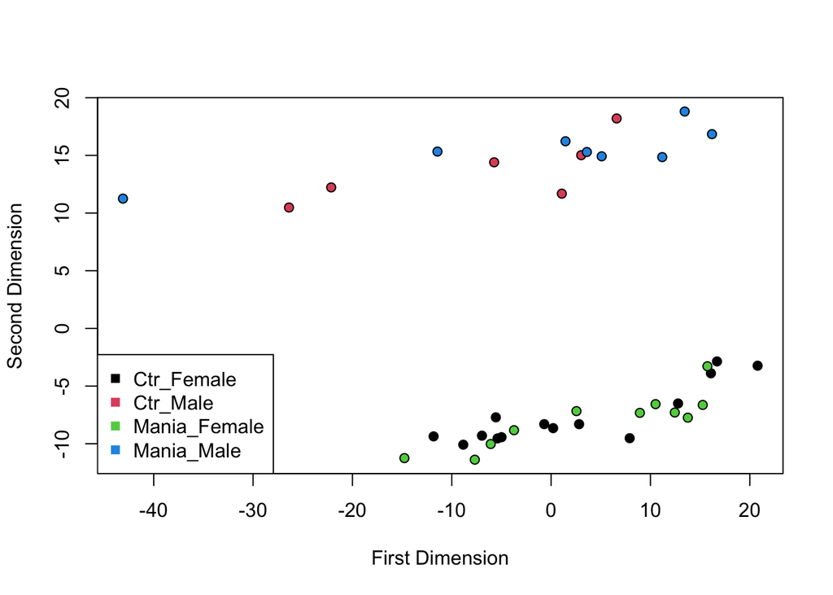

```r
# Calculate distances and multidimentional scaling
d = dist(t(beta))
mds <- cmdscale(d)

plot(mds[,1], mds[,2], bg = as.numeric(strata), pch = 21,
     xlab = "First Dimension", ylab = "Second Dimension")
legend("bottomleft", levels(strata), col = seq(along = levels(strata)), pch=15)
```

It is clear from the previous plot that the patient’s sex is highly correlated with the distance between the samples. The methylation values of the sex chromossomes were removed to simplify the dataset and remove this confounding factor.

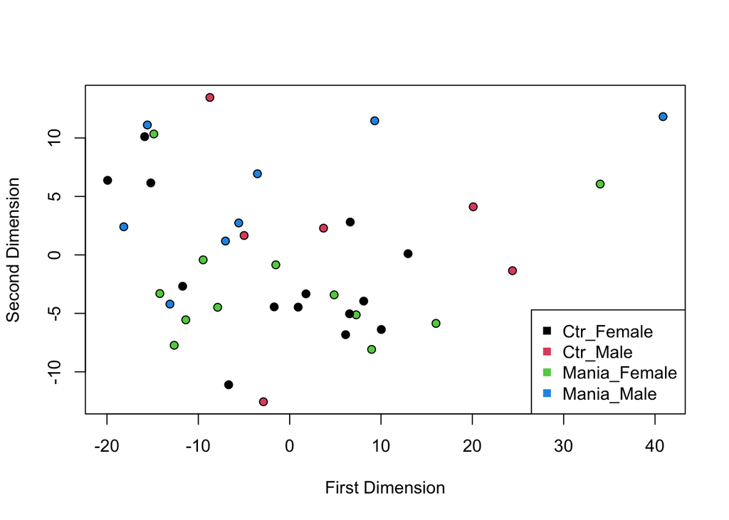

```r
# Identify the  probes matching the autosomes
idx <- which(rowSums(is.na(beta)) == 0 & seqnames(GRset) %in% paste0("chr", 1:22))
GRset <- GRset[idx]
beta <- getBeta(GRset)

# Calculate distances and multidimentional scaling
d = dist(t(beta))
mds <- cmdscale(d)
plot(mds[,1], mds[,2], bg = as.numeric(strata), pch = 21,
     xlab = "First Dimension", ylab = "Second Dimension")
legend("bottomright", levels(strata), col = seq(along = levels(strata)), pch=15)
```

## DNAm age

[Horvath 2013](https://www.ncbi.nlm.nih.gov/pmc/articles/PMC4015143/) has shown that methylation of a specific set of CpG locations in the genome is highly correlated with age, proposing a model to estimate the DNA methylation (DNAm) age as a cellular biomarker of the chronomolical age from methylation data.

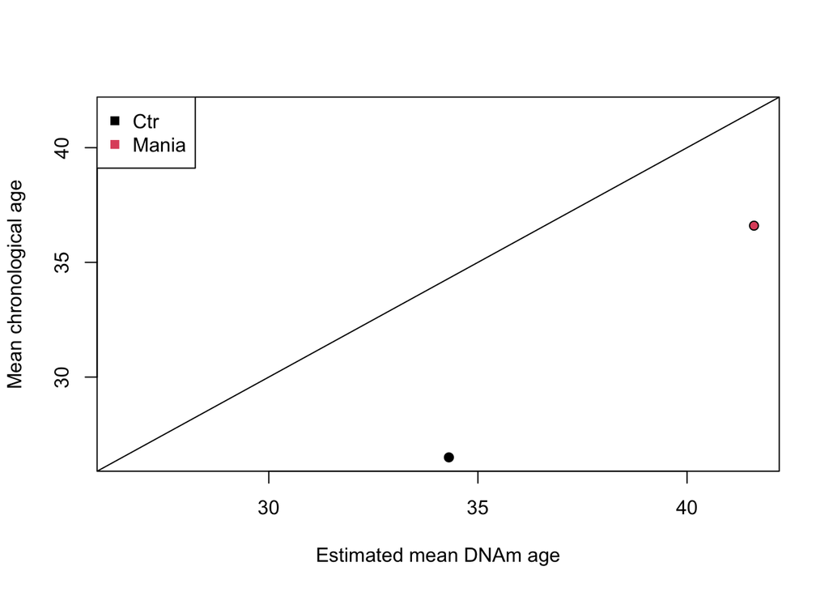

```r
# Estimate DNAm age
ages <- DNAm_clock(beta)
ages$groups <-  pheno$group

# Patient age is not provided in the original repoert, but it contain the mean age of the patient groups
group_means <- c("Control" = 26.5, "Mania" =  36.6)
DNAmAge_mean <- by(ages$DNAmAge, ages$groups, mean)

axlim <- c(min(DNAmAge_mean,group_means), max(DNAmAge_mean,group_means))
plot(DNAmAge_mean, group_means, bg = as.factor(levels(ages$groups)), pch = 21,
     xlab = "Estimated mean DNAm age", ylab = "Mean chronological age",  xlim = axlim, ylim = axlim )
legend("topleft", levels(ages$groups), col = seq(along = levels(ages$groups)), pch=15)
abline(0,1)
```

Without the actual patient age, it is difficult to interpret the differences observed, as it could result from a few outlier predictions or a generalised overestimation as reported on a study with [bangladeshi patients](https://bmcgenomics.biomedcentral.com/articles/10.1186/s12864-019-6039-9).

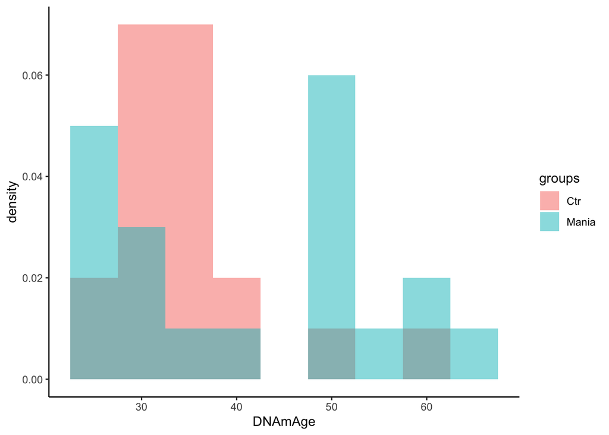

```r
ggplot(ages, aes(DNAmAge, fill = groups)) +
  geom_histogram(alpha = 0.5, aes(y = ..density..),binwidth = 5, position = 'identity') +
  theme_classic()
```

From the distribution of DNAm predicted ages, it seems like mania patients are epigenetically older than control patients. However, such a difference is reported and expected from the original report. In addition, the difference in means observed for both groups is approximatly the same, suggesting that, instead of an acelarated epigenetic age, this difference may correspond to a real chronological age difference.

A decrease in overall methylation with age has been often described. This phenomenon can also be visualised, demonstrating a very slightly downward trend of the average methylation with age, though not having a major effect on global methylation levels.

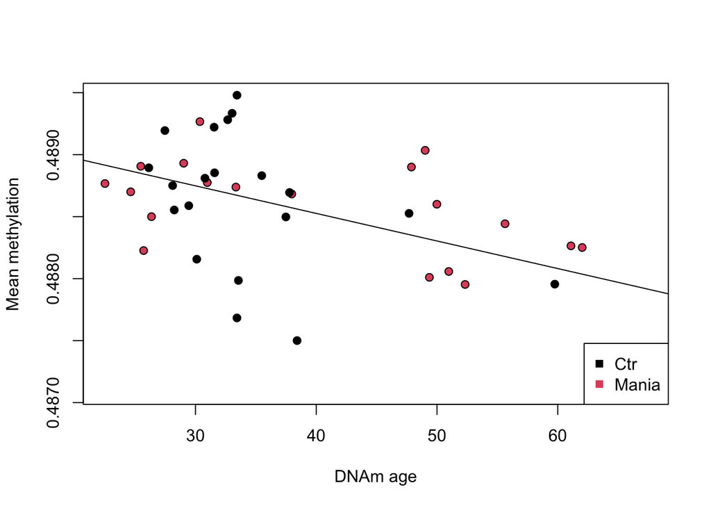

```r
y <- colMeans(beta)

plot(ages$DNAmAge, y , bg = as.numeric(ages$groups), pch = 21,
     xlab = "DNAm age", ylab = "Mean methylation")
legend("bottomright", levels(ages$groups), col = seq(along = levels(ages$groups)), pch=15)
abline(lm(y ~ ages$DNAmAge))
```

## Cell type composition

[*Jaffe 2014*](https://genomebiology.biomedcentral.com/articles/10.1186/gb-2014-15-2-r31) noticed that biological findings in blood samples can often be confounded with cell type composition, suggesting methylation differences associated with age may be counfouded with changes in cellular proportions over time. In their report, a model for cell type decomposition of blood samples based on methylation profiles to allows easy estimation the sample’s cell type composition is proposed, which is integrated on the `minfi` R package.

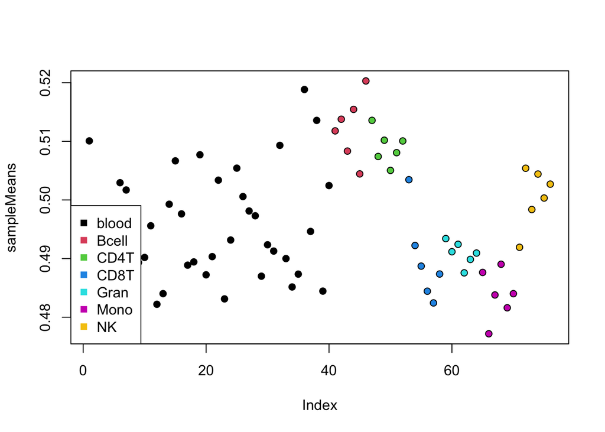

```r
cellCounts <- estimateCellCounts(rgSet,meanPlot = TRUE)
```

The plot produced depicts the average DNA methylation across the cell-type discrimating probes in both the provided data (black) and the model datafor sorted populations (color). As the provided samples (blood) are an heterogeneous mixture of pure populations, the means from the tested samples is expected to be within the range of the sorted samples, which is the case.

### Effect of age on cellular populations

Even though both the age and cell content are unconfirmed estimations, it would be interesting to understand if these two variables may show any association as previously reported.

```r
lreg <- lm(ages$DNAmAge ~ cellCounts)
anova(lreg)
## Analysis of Variance Table
##
## Response: ages$DNAmAge
##            Df Sum Sq Mean Sq F value    Pr(>F)
## cellCounts  6   3252  542.00  7.5374 3.843e-05 ***
## Residuals  33   2373   71.91
## ---
## Signif. codes:  0 '***' 0.001 '**' 0.01 '*' 0.05 '.' 0.1 ' ' 1
```

From the analysis of variance, it looks like there is a significant association between predicted age and predicted cell proportions. To better understand this associations, the cell proportion of significantly associated populations is ploted for visualization.

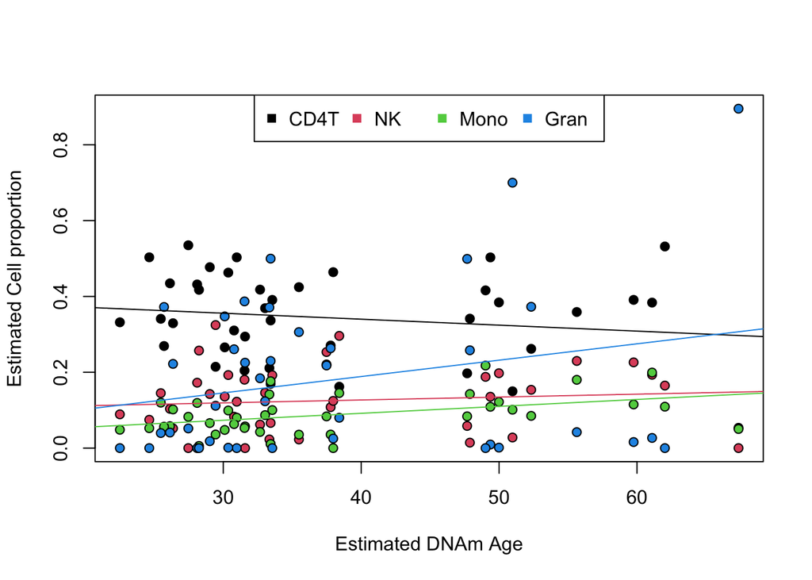

```r
# Correct sample names
ages$SampleID <- gsub("^X", "", ages$SampleID )
# Extract cell populations significantly with age
sig_pops <- summary(lreg)$coef[,"Pr(>|t|)"] < 0.05

# Prepare data for ploting
plot_data <- as.data.frame(cbind("SampleID" = rownames(cellCounts), cellCounts))
plot_data <- merge(plot_data, ages)
plot_data <- plot_data[,c("SampleID", "DNAmAge", gsub("cellCounts", "", names(sig_pops[sig_pops])))]

plot_data <- melt(plot_data, id.vars = c("SampleID", "DNAmAge"))
plot_data$variable<- as.factor(plot_data$variable)
plot_data$value <- as.numeric(plot_data$value)

# Plot data
plot(plot_data$DNAmAge, plot_data$value, bg = plot_data$variable, pch = 21,
     xlab = "Estimated DNAm Age", ylab = "Estimated Cell proportion")
# Add regression lines
for (i in  1:length(levels(plot_data$variable))) {
  tmp <-  plot_data[plot_data$variable == levels(plot_data$variable)[i],]
  treg <- lm(tmp$value ~ tmp$DNAmAge)
  abline(treg, col = i)
}
legend("top", levels(plot_data$variable), col = seq(along = levels(plot_data$variable)), pch=15, horiz=TRUE)
```

Though there is noticeable variation in the estimated cell proportions, the trends represented by the regression lines are clear: the proportion of Granulocytes, NK and Monocytes increate with age while that of CD4 T-cells decrease. These results seem to capture the cellular changes previously described to occurs with age, including the steep decline of CD4 cells (likely due to the thymus involution) and the granulocytes increasing representativeness.

The main differences are the failure to detect the decrease in B cell and CD8 T-cells proportions, though closer observation of the publised results seem to suggest this may be associated with the narrower age window analysed in this report: the proportion of B cell population was previously found to decrease more drastically in the early years (up to 30-40 years) while the CD8 T-cell proportion show an inflection point around 40 years old, suggesting that the observable changes in the proportions of this particular cell population are dependent on the time frame considered.

# Differentially methylated regions

Because the presence of SNPs inside the probe body or at the nucleotide extension can have important consequences on the downstream analysis, it is strongly recommend to drop the probes that contain either a SNP at the CpG interrogation or at the single nucleotide extension.

```r
GRset <- dropLociWithSnps(GRset, snps=c("SBE","CpG"), maf=0)
beta <- getBeta(GRset)
```

To explore the methylation differences between patients diagnosed with mania and controls, single position differentially methylated positions (DMPs) were determined using a linear model adjusted for the estimated age and cell populations was fit to the bete values previously calculated.

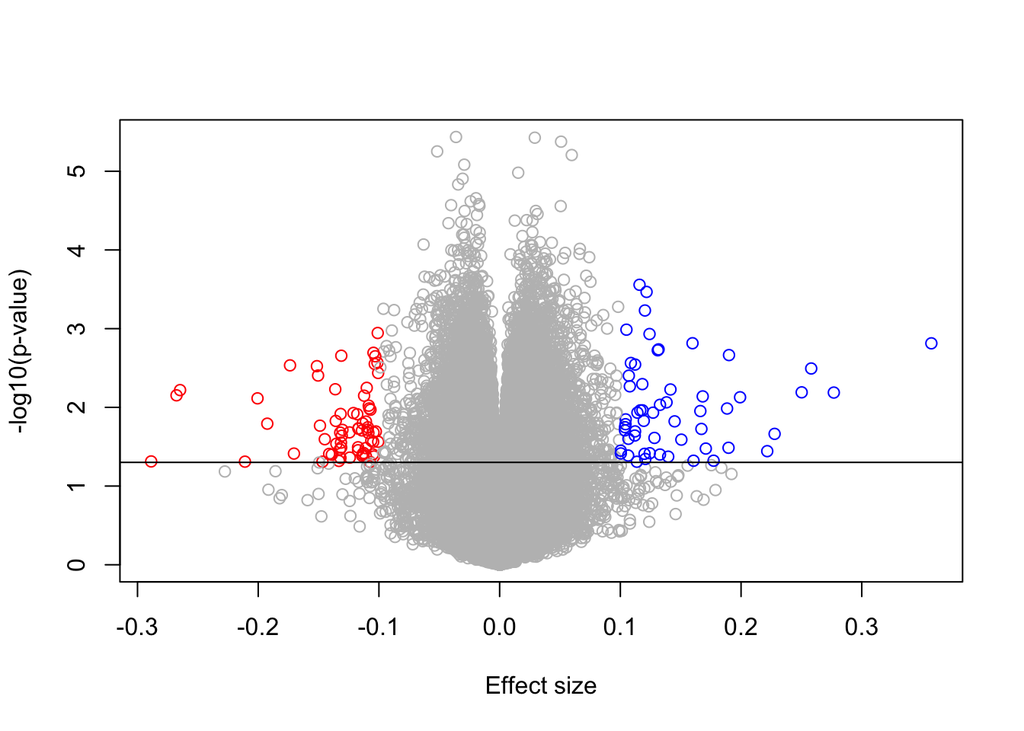

```r
# Define and test model
X = model.matrix(~pheno$group + ages$DNAmAge + cellCounts)
fit = lmFit(beta,X)
eb = eBayes(fit)
pvals = eb$p.value[,2]

# Volcano plot
volcano_plot(fit$coefficients[,2], pvals, threshold = 0.1)
```

```r
# Adjusted p-values
qvals <- qvalue(pvals)$qvalues
paste("There are", sum(qvals < 0.05), "significant DMP were found after adjustment for multiple testing")
```

```
## [1] "There are 0 significant DMP were found after adjustment for multiple testing"
```

The statistical analysis finds a number of significantly DMPs but none of these positions retains significance once adjusted for multiple testing. However, DMPs have been shown to be generally not as predictive, or informative, as differentially methylated region (DMR). DMRs are groups of consecutive GpG locations that are differentially methylated in the same direction between two conditions, thus representing larger scale and more consistent genomic modifications. As such, this report looks at DMRs regions associated with the mania condition.

Ideally, the model tested would be corrected for age and cell proportion as in the previous model as these two covariates are known confounders with methylation. Unfortunatly, it is not recommended to use multiple covariates when using `bumpfinder` permutation test as permutation is computational demanding. This analysis is thus simplified but this caveat should be kept in mind.

```r
# Identify DMRs
designMatrix <- model.matrix(~ pheno$group)
dmrs <- bumphunter(GRset, design = designMatrix, cutoff = 0.05, B=200, type="Beta")

tab <- dmrs$table
sig_regions <- tab$fwerArea <= 0.1
tab[sig_regions,]
```

```
##       chr    start      end      value     area cluster indexStart indexEnd  L
## 2228 chr6 29648360 29649084 -0.1084549 1.735279  157824     153500   153515 16
##      clusterL p.value fwer  p.valueArea fwerArea
## 2228       22       0    0 1.545523e-05     0.03
```

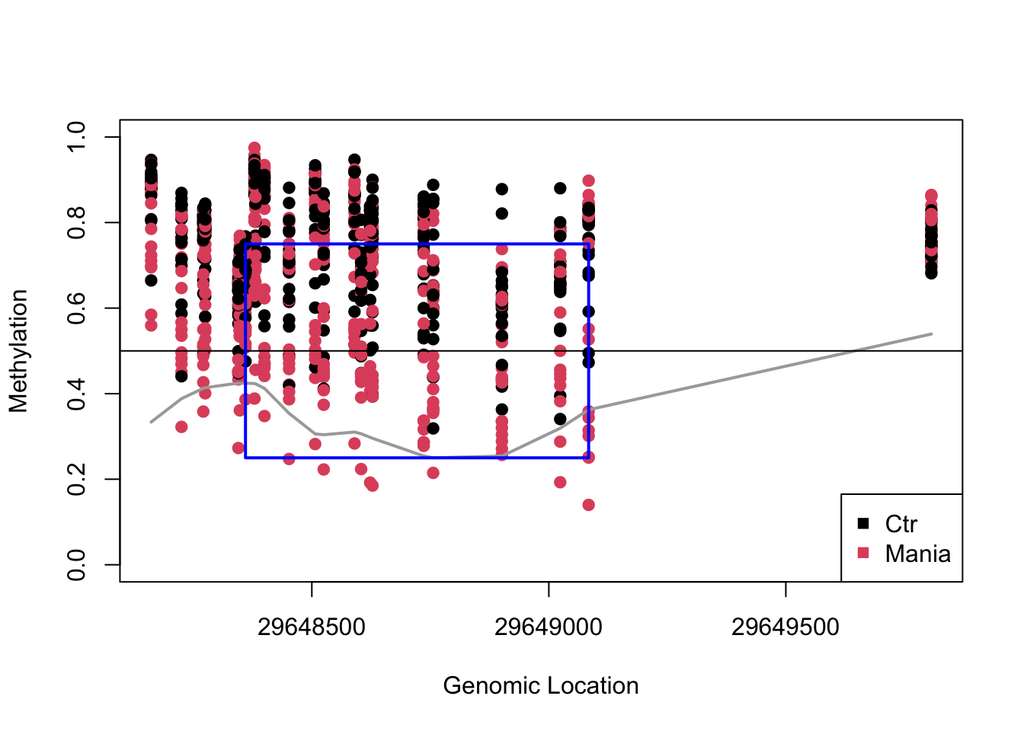

```r
# Extract the positions of the most significant region
pos <- start(granges(GRset))
Index=(tab[1,"indexStart"]-6):(tab[1,"indexEnd"]+1)
x = pos[Index]

# Extract the adjusted model coefficients and fit a smoothing function
diff <- fit$coef[Index,2]
ldiff <- loess(diff~x)

# Artifitially expand the values to make visualization easierl

ldiff <- ldiff$fitted/max(abs(ldiff$fitted))/4 + 0.5

# Plot the most significant regions
matplot(x, beta[Index,,drop=TRUE],bg = as.numeric(pheno$group), col =as.numeric(pheno$group) ,pch=21,
        xlab="Genomic Location",ylab="Methylation",ylim=c(0,1))

lines(x=x, y=ldiff, col = "darkgrey", lwd = 2)
abline(h= 0.5)
rect(xleft = tab[1,"start"], ybottom = 0.25, xright = tab[1,"end"], ytop =0.75, lwd = 2, border = "blue")
legend("bottomright", levels(pheno$group), col = seq(along = levels(pheno$group)), pch=15)
```

The smooth fit of the methylation differences (adjusted for estimated cell proportion and age) is shown as a solid grey line suggesting a slight hypomethylation *(values are expanded for visualisation)* in the significant region identified (blue box). It is clear that, in this region, mania patients (red) are less methylationed, on average, than control patients (black).

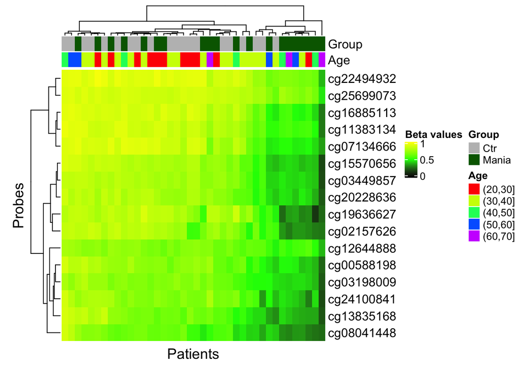

```r
# Extract location of probes withing significant regions
sig_probes <- sapply(which(sig_regions), function(i) (tab[i,"indexStart"]):(tab[i,"indexEnd"]))
sig_probes <- sort(unlist(sig_probes))
sig_probes <- names(granges(GRset))[sig_probes]

# Prepare data for plotting
mat = beta[sig_probes,]

age <- cut(ages$DNAmAge, breaks = c(20, 30, 40, 50, 60, 70))
age_col <- rainbow(length(levels(age)))
names(age_col) <- levels(age)

ha = HeatmapAnnotation(Group = pheno$group, Age = age,
                       col = list(
                         Group = c("Ctr" = "grey", "Mania" = "darkgreen"),
                         Age = age_col)
                         )

Heatmap(mat, name = "Beta values", column_title = "Patients",  column_title_side = "bottom",
    row_title = "Probes", row_title_rot = 90,
    col = colorRamp2(c(0, 0.5, 1), c("black", "green", "yellow")),
    top_annotation = ha, show_row_names = TRUE, show_column_names = FALSE)
```

The heatmap clustering the beta values for the probes within the significant DMRs identify a subgroup of mania patients with decreased methylation. Patients classified has mania reflect various types of mental conditions according to the original report, suggesting that hypomethylation may be playing a significant role in some types of mania, but not in others. More detailed clinical data would be required to test this hypothesis.

### Probe Annotation

```r
# Get probe annotation
annot <- getAnnotation(GRset)[sig_probes,]
# Identify GpC classification
CpGs <- annot$Relation_to_Island
# Identify GpC association with genes
genes <- annot$UCSC_RefGene_Name

cat(paste("Probes within the identified significant DMRs are located to", unique(CpGs), "regions and associated with", sum(genes != ""), "genes"))
## Probes within the identified significant DMRs are located to OpenSea regions and associated with 0 genes
```

Analysis of [Hi-C](https://en.wikipedia.org/wiki/Chromosome_conformation_capture) data has shown that the genome can be divided into two compartments (A/B compartments) that are cell-type specific and are associated with open and closed chromatin respectively. [Fortin and Hansen 2015](https://genomebiology.biomedcentral.com/articles/10.1186/s13059-015-0741-y) shows that approximately 170,000 open sea probes on the 450k array can be used to estimate these compartments from methylation data.

```r
# Extracted control, mania and probe data
tab_sig = makeGRangesFromDataFrame(tab[sig_regions,],keep.extra.columns = TRUE)
GRset_ctr <- GRset[,pheno$group == "Ctr"]
GRset_mania <- GRset[,pheno$group == "Mania"]
# Estimate compartments for controls
ctr_comp <- compartments(GRset_ctr, chr="chr6", resolution=100*1000, keep = FALSE)
ctr_sig <- findOverlaps(tab_sig,ctr_comp)
ctr_comp <- mcols(ctr_comp)$compartment

# Estimate compartments for mania patients
mania_comp <- compartments(GRset_mania, chr="chr6", resolution=100*1000, keep = FALSE)
mania_sig <- findOverlaps(tab_sig,mania_comp)
mania_comp <- mcols(mania_comp)$compartment

cat(paste("Significant probes on control patients are predicted to be in a", ctr_comp[subjectHits(ctr_sig)], "compartment and on a", mania_comp[subjectHits(mania_sig)], "for mania patients/nHowever, for chromossome 6 there are", table(ctr_comp, mania_comp)[1,2], "probes that are preticed to have different conformations"))
## Significant probes on control patients are predicted to be in a closed compartment and on a closed for mania patients/nHowever, for chromossome 6 there are 151 probes that are preticed to have different conformations
```

As suggested by the weak differences in methylation identified, both control and mania chromatin is predicted to be in a closed state, and thus inactive in the significante DMRs. However, 151 comparmentments out of 580 are predicted to have different genomic conformations between the two patent groups on chromossome 6.